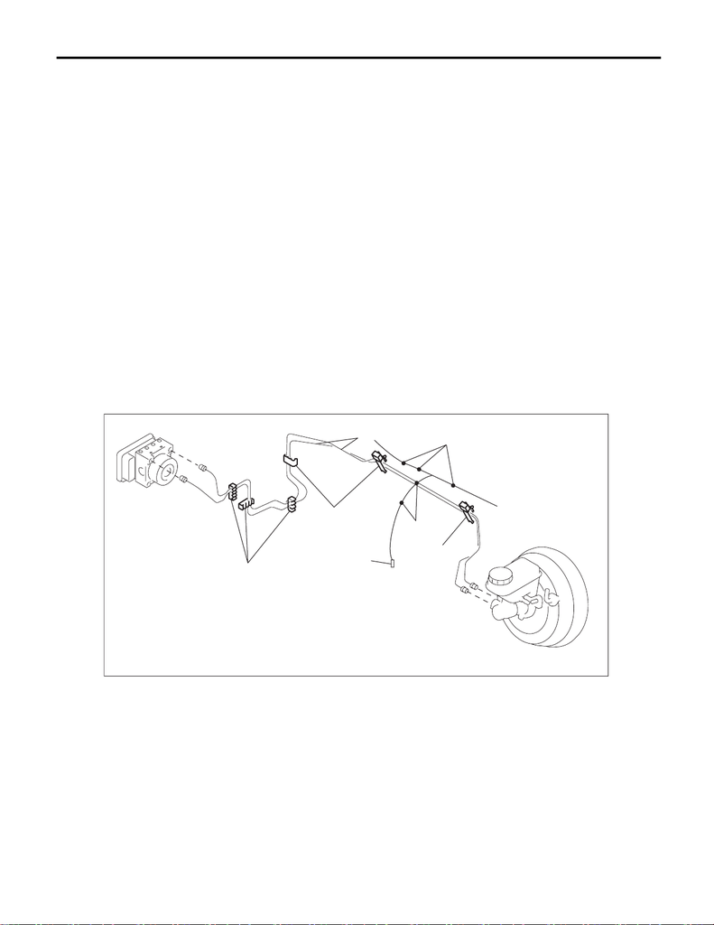

BR-55

Brake Booster

BRAKE

9. Brake Booster

A: REMOVAL

CAUTION:

• Do not allow brake fluid to come in contact with the painted surface of the vehicle body. If it does,

wash off with water and wipe away completely.

• Before performing service on the airbag module, always refer to “CAUTION” of “General Descrip-

tion” in “AIRBAG SYSTEM” section. <Ref. to AB-9, CAUTION, General Description.>

1) Disconnect the ground cable from battery and wait for at least 60 seconds before starting work. <Ref. to

NT-5, BATTERY, NOTE, Note.>

NOTE:

For models other than STI model, disconnect the ground terminal from battery sensor.

2) Remove the intercooler.

• Except for STI model <Ref. to IN(w/o STI)-38, REMOVAL, Intercooler.>

• STI model <Ref. to IN(STI)-13, REMOVAL, Intercooler.>

3) Disconnect the air conditioner pipe. <Ref. to AC-63, REMOVAL, Hose and Pipe.>

4) Remove the power steering control module. (Except for STI model) <Ref. to PS-84, REMOVAL, Power

Steering Control Module.>

5) Remove the vacuum hose.

6) Remove the master cylinder assembly. <Ref. to BR-52, REMOVAL, Master Cylinder.>

7) Remove the brake pipe assembly (a).

(1) Disconnect the starter connector (b) and harness clip (c).

(2) Remove the brake pipe assembly (a) from the pipe clip (d).

8) Remove the cover assembly - instrument panel LWR driver. <Ref. to EI-61, REMOVAL, Instrument Panel

Lower Cover.>

9) Remove the knee airbag module. <Ref. to AB-25, KNEE AIRBAG MODULE, PROCEDURE, Airbag Con-

nector.>

10) Remove the column assembly - steering. <Ref. to PS-25, REMOVAL, Steering Column.>

BR-01307

(c)

(d)

(c)

(b)

(d)

(d)

(a)

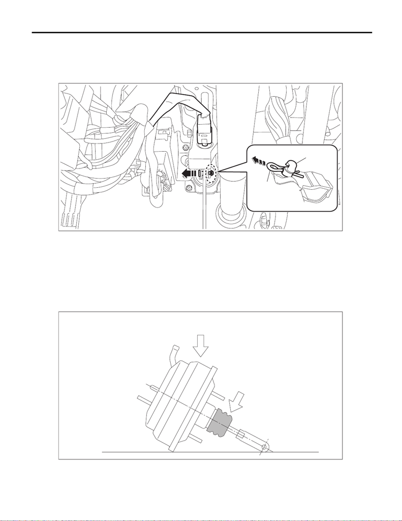

BR-56

Brake Booster

BRAKE

11) Remove the snap pin (a) and clevis pin (b), and remove the operating rod from the brake pedal.

CAUTION:

• Be careful not to apply excessive force to the operating rod when handling the operating rod. The

angle may change by ±3°, and it may result in damage to power piston cylinder.

• Do not change the push rod length.

12) Remove the vacuum booster assembly.

CAUTION:

• Do not disassemble the vacuum booster assembly.

• Make sure that the booster shell and vacuum pipe are not subject to strong impacts.

• Be careful not to drop the vacuum booster assembly. If the vacuum booster assembly is dropped

accidentally, replace it.

• Be careful when placing the vacuum booster assembly on floor.

• If external force (a) is applied from above when the vacuum booster assembly is placed in this po-

sition, the resin portion as indicated by “P” may become damaged.

(a)

(b)

BR-01213

(a)

P

BR-00955

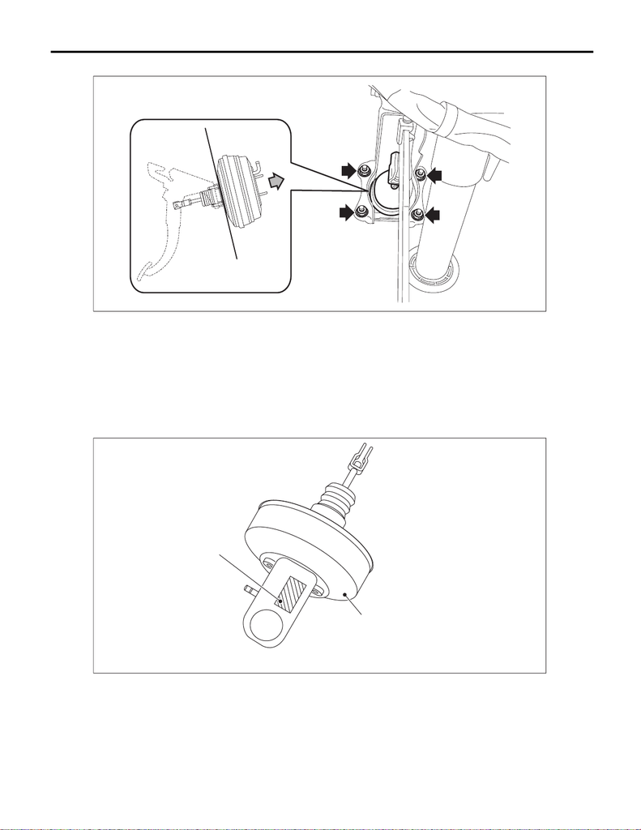

BR-57

Brake Booster

BRAKE

(1) Remove the nuts, and then remove the vacuum booster assembly.

B: INSTALLATION

CAUTION:

• When replacing the brake booster, adhere the label to the position shown in the figure. (C0 model)

• Before performing service on the airbag module, always refer to “CAUTION” of “General Descrip-

tion” in “AIRBAG SYSTEM” section. <Ref. to AB-9, CAUTION, General Description.>

Label:

C0 model

Part No. 25080GA010

(a) Label (b) Brake booster

BR-00850

BR-01240

(a)

(b)

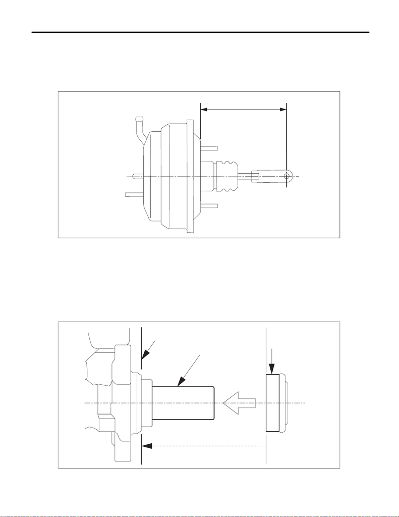

BR-58

Brake Booster

BRAKE

1) Check and adjust the operating rod of the vacuum booster assembly.

(1) Measure the length between the vacuum booster assembly mounting surface and clevis pin hole.

(2) If it is not within the specification, loosen the lock nut, rotate the vacuum booster assembly operating

rod to adjust the rod length.

Specification L:

136.3 mm (5.37 in)

2) Install the vacuum booster assembly.

Tightening torque:

18 N·m (1.8 kgf-m, 13.3 ft-lb)

CAUTION:

• Apply grease to the snap pin to prevent the operating rod from wear.

• Replace the clevis pin with new parts, and apply thin coat of NIGTIGHT LYW No. 2 grease to the cle-

vis pin.

• When installing the master cylinder assembly, replace the seal sub assembly with a new part, and

install it to the vacuum booster assembly.

(a) Primary piston (b) Seal sub ASSY (c) Install the seal sub ASSY to this

surface.

L

BR-00957

(c)

(a)

(b)

BR-00948

[figure not shown]

BR-59

Brake Booster

BRAKE

3) Install the column assembly - steering. <Ref. to PS-28, INSTALLATION, Steering Column.>

4) Install the knee airbag module.

Tightening torque:

7.5 N·m (0.8 kgf-m, 5.5 ft-lb)

5) Install the cover assembly - instrument panel LWR driver.

6) Install the master cylinder assembly. <Ref. to BR-53, INSTALLATION, Master Cylinder.>

7) Install the air conditioner pipe. <Ref. to AC-9, AIR CONDITIONING UNIT, COMPONENT, General De-

scription.>

8) Install the intercooler.

• Except for STI model: <Ref. to IN(w/o STI)-41, INSTALLATION, Intercooler.>

• STI model: <Ref. to IN(STI)-14, INSTALLATION, Intercooler.>

9) Charge refrigerant. <Ref. to AC-27, PROCEDURE, Refrigerant Charging Procedure.>

10) Bleed air from the brake system. <Ref. to BR-65, PROCEDURE, Air Bleeding.>

11) Connect the battery ground terminal. <Ref. to NT-5, BATTERY, NOTE, Note.>

NOTE:

For models other than STI model, connect the ground terminal to battery sensor.

12) Perform a road test to make sure the brakes do not drag.

C: INSPECTION

1. OPERATION CHECK WHEN NOT USING MEASURING DEVICES

CAUTION:

When checking operation, be sure to apply the parking brake securely.

When an operation check is performed with no measuring devices, a faulty part cannot be identified correctly.

But it is possible to identify the outline of the defect by performing the check according to the following pro-

cedures.

• Air tightness check

1) Start the engine, and idle it for 1 to 2 minutes, then turn it OFF.

2) Depress the brake pedal several times applying the normal pedal force.

NOTE:

The pedal stroke should be the longest at the 1st depression, and it should become shorter at each succes-

sive depression.

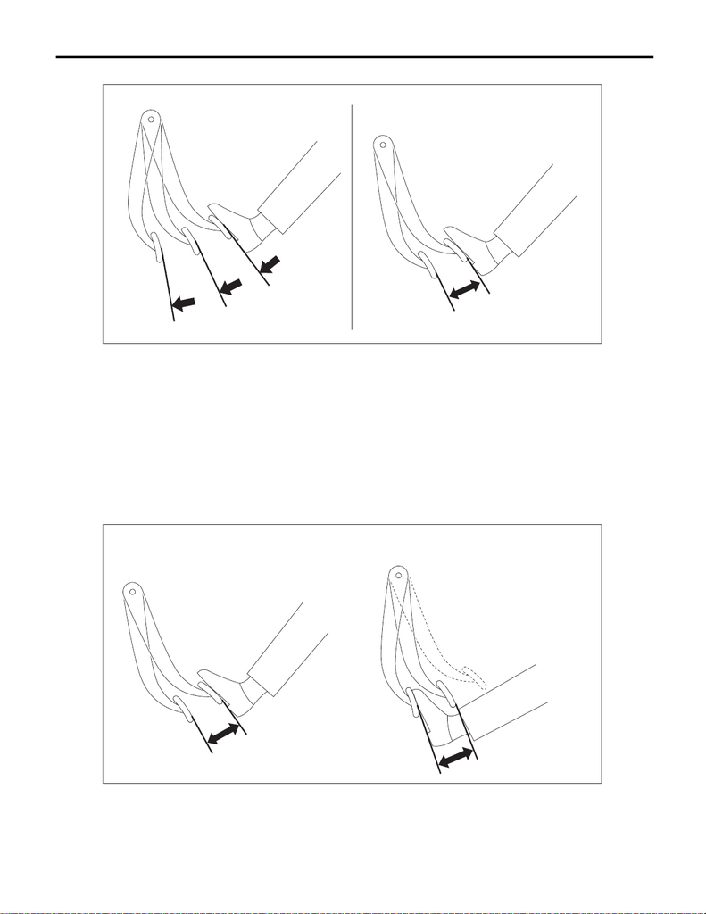

BR-60

Brake Booster

BRAKE

3) If no change occurs in the pedal height when pressed, the vacuum booster assembly is faulty.

NOTE:

• In case of defective operation, inspect the condition of the check valve and vacuum hose as well.

• Replace them if faulty, and perform the test again.

• If no improvement is observed, check precisely with gauges.

• Check operation

1) While the engine is OFF, depress the brake pedal several times applying the same pedal force, to check

for a change in pedal height.

(A) Normal (B) Not OK

(a) 1st (b) 2nd (c) 3rd

(a) When engine is stopped (b) When engine is started

(A)

(a)

(b)

(c)

(B)

BR-00937

(a)

(b)

(c)

(a) (b)

BR-00938

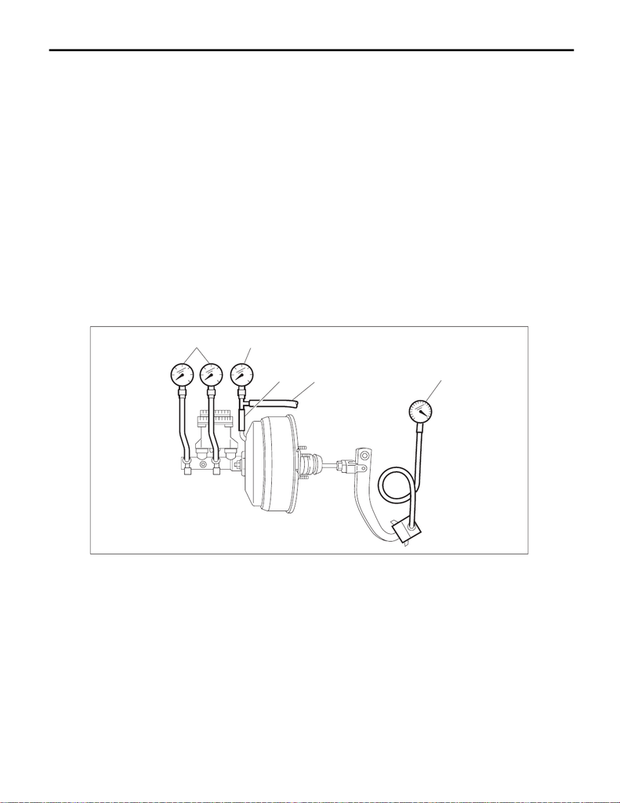

BR-61

Brake Booster

BRAKE

2) With the brake pedal depressed, start the engine.

3) As the engine starts, the brake pedal should move slowly toward the floor. If the pedal height does not

change, the vacuum booster assembly is faulty.

NOTE:

If a faulty part is detected after inspection, check precisely with measuring devices.

• Loaded air tightness check

Depress the brake pedal while the engine is running, and turn the engine to OFF while the pedal is de-

pressed.

Keep the pedal depressed for 30 seconds. If the pedal height does not change, the function of vacuum boost-

er assembly is normal. If the pedal height increases, it is faulty.

NOTE:

If a faulty part is detected after inspection, check precisely with measuring devices.

2. OPERATION CHECK WHEN USING MEASURING DEVICES

CAUTION:

When checking operation, be sure to apply the parking brake securely.

• Check with measuring devices

Connect a measuring device as shown in the figure. After bleeding air from the pressure gauge, perform

each check.

(a) Pressure gauge (c) Adapter hose (e) Pedal force gauge

(b) Vacuum gauge (d) Vacuum hose

(a) (b)

(c) (d)

(e)

BR-00939

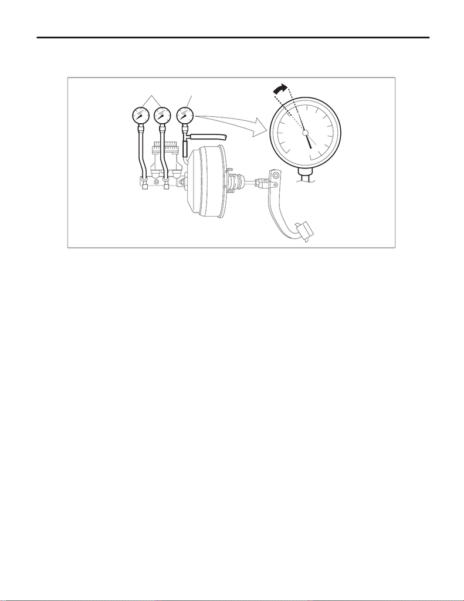

BR-62

Brake Booster

BRAKE

• Air tightness check

1) Start the engine and keep it running at idle until vacuum pressure indicates 66.7 kPa (500 mmHg, 19.69

inHg) while the brake pedal is not depressed.

2) Stop the engine and check the vacuum pressure.

If the value matches the following standard, the vacuum booster assembly function is normal.

Vacuum pressure: standard

The range of vacuum pressure drop within 15 seconds after stopping the engine is 3.3 kPa (25 mm-

Hg, 0.98 inHg) or less.

If a faulty part is detected after inspection, it may results from one of the following causes.

• Check valve malfunction

• Leak from vacuum hose

• Leak from shell joint section or stud bolt welded section

• Damaged diaphragm

• Leak from valve body seal and bearing section

• Leak from plate and seal assembly section

• Leak from poppet valve assembly section

(a) Pressure gauge (b) Vacuum gauge

(a) (b)

BR-00940

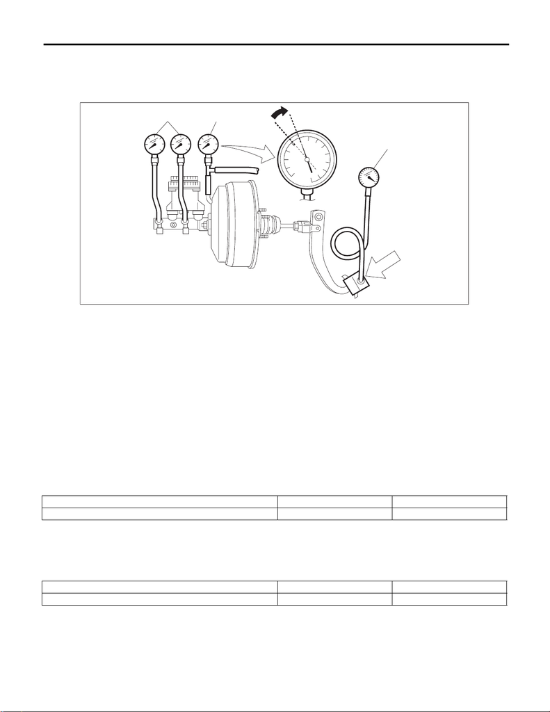

BR-63

Brake Booster

BRAKE

• Loaded air tightness check

1) Start the engine and depress the brake pedal with a pedal force of 196 N (20 kgf, 44 lbf).

2) Keep the engine running at idle and the pedal depressed until vacuum pressure of the vacuum gauge in-

dicates 66.7 kPa (500 mmHg, 19.69 inHg).

3) Stop the engine and check the vacuum gauge.

If the value matches the following standard, the vacuum booster function is normal.

Vacuum pressure: standard

The range of vacuum pressure drop within 15 seconds after stopping the engine is 3.3 kPa (25 mm-

Hg, 0.98 inHg) or less.

If a faulty part is detected after inspection, refer to “AIR TIGHTNESS CHECK”.

<Ref. to BR-59, INSPECTION, Brake Booster.>

4) If the vacuum booster assembly is faulty, replace it with a new part.

• Lack of boost action check

1) Turn the engine OFF, and set the value of the vacuum gauge to “0”.

2) Check the fluid pressure when the brake pedal is depressed. The pressure must be greater than the spec-

ification listed.

• Boosting action check

1) Set the vacuum gauge reading to 66.7 kPa (500 mmHg, 19.69 inHg) with the engine running.

2) Check the fluid pressure when the brake pedal is depressed. The pressure must be greater than the spec-

ification listed.

(a) Pressure gauge (c) Pedal force gauge (d) Depressed

(b) Vacuum gauge

Brake pedal force: N (kgf, lbf) 147 (15, 33) 294 (30, 66)

Fluid pressure: kPa (kgf/cm

2

, psi) 471 (4.8, 68.3) 1,385 (14.1, 200.8)

Brake pedal force: N (kgf, lbf) 147 (15, 33) 294 (30, 66)

Fluid pressure: kPa (kgf/cm

2

, psi) 4,880 (49.8, 707.6) 9,750 (99.4, 1413.7)

(a) (b)

(c)

(d)

BR-00941